# Voting behavior in BiH Parliament

Roland Schmidt

12/3/2019

## Context

A while ago I noticed that the website of Bosnia’s parliament now also provides the voting records for each separate vote taken in both houses. These records also include the voting behavior for each individual MP. While the dominant role of the ethnic cleavage in Bosnian politics has been a constant theme and continuously emphasized for the last 25 years (to an extent which frequently blanks out other salient issues), I hadn’t seen any empirical record on MP’s voting behavior which could cooroberate the cleavage’s prevalence in the legislative arena (one insightful exception is Birgit Kunrath’s 2011 [paper](https://www.cambridge.org/core/journals/nationalities-papers/article/of-veto-players-and-entityvoting-institutional-gridlock-in-the-bosnian-reform-process/96BB80A5191E12B40F501841546C151D)).

This post digs into the now available records for the 2014-2018 parliament and seeks to shed some light on the legislative process. The first part presents the output, the second highlights the most relevant steps in R to produce them. The entire code for the analysis is again available on my [github account](http://www.github.com/werkstattcodes).

# Results

## Number of bills considered in both chambers and outcome.

Overall, during the 2014 to 2018 parliament session 163 bills were considered. Out of this total, only 37 % were eventually passed and published to become law. 38 % of all bills were rejected in at least one of both houses.

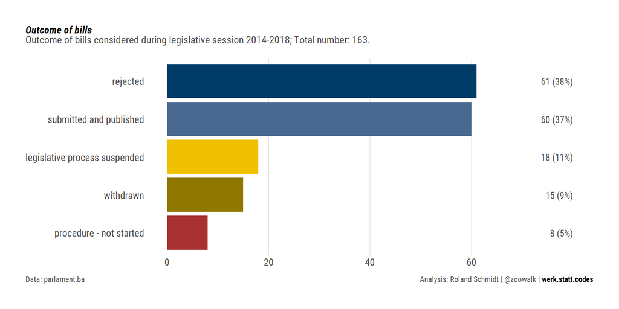

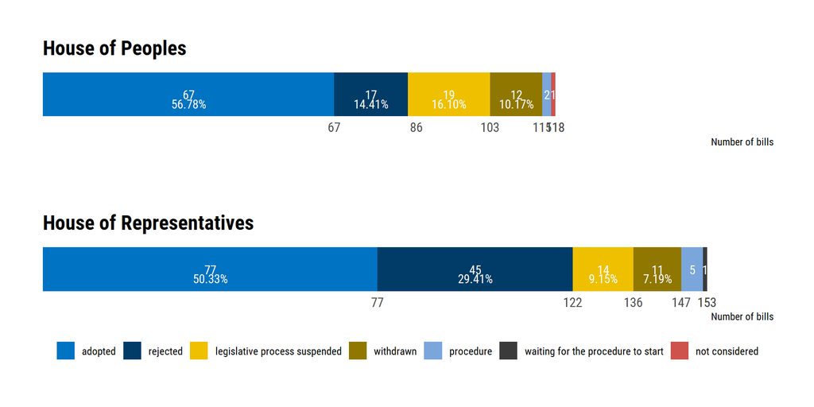

Out of the 67 bills adopted in the House of Peoples and 77 in the House of Representatives, 60 were acutally considered in both chamber and eventully passed. This With 37.0 % of all bills it’s the largest category in our table. The second largest category comprises 27 bills (16.7 % of all bills) which were rejected in the House of Representatives and never made it to the House of Peoples. The third largest category contains 12 bills (7.4 % of all bills) which were adopted in the lower house but rejected in the upper chamber.

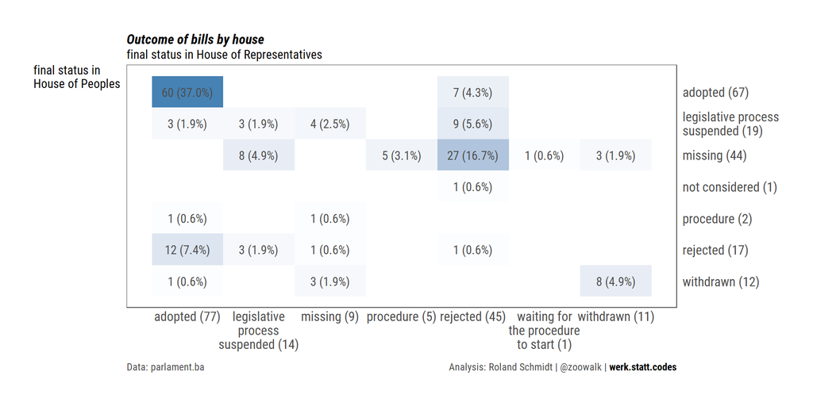

## time line

How was legislative activity distributed over time? As the graph below shows, both chamber were most active in the first half of 2016 and the end of 2017. I am not sure exactly what caused this bout of activity, but it’s quite distinct if contrasted e.g. wtih 2015 or the early parts of 2017.

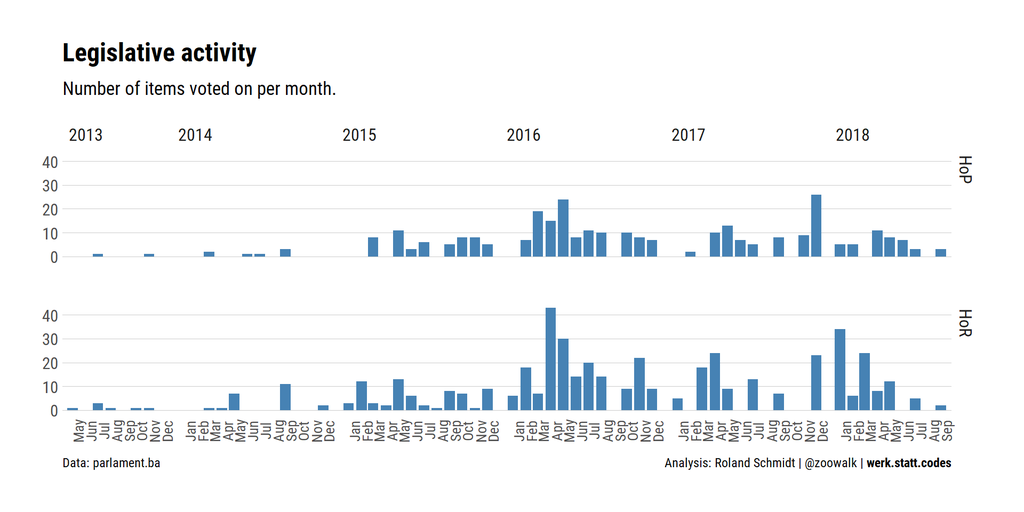

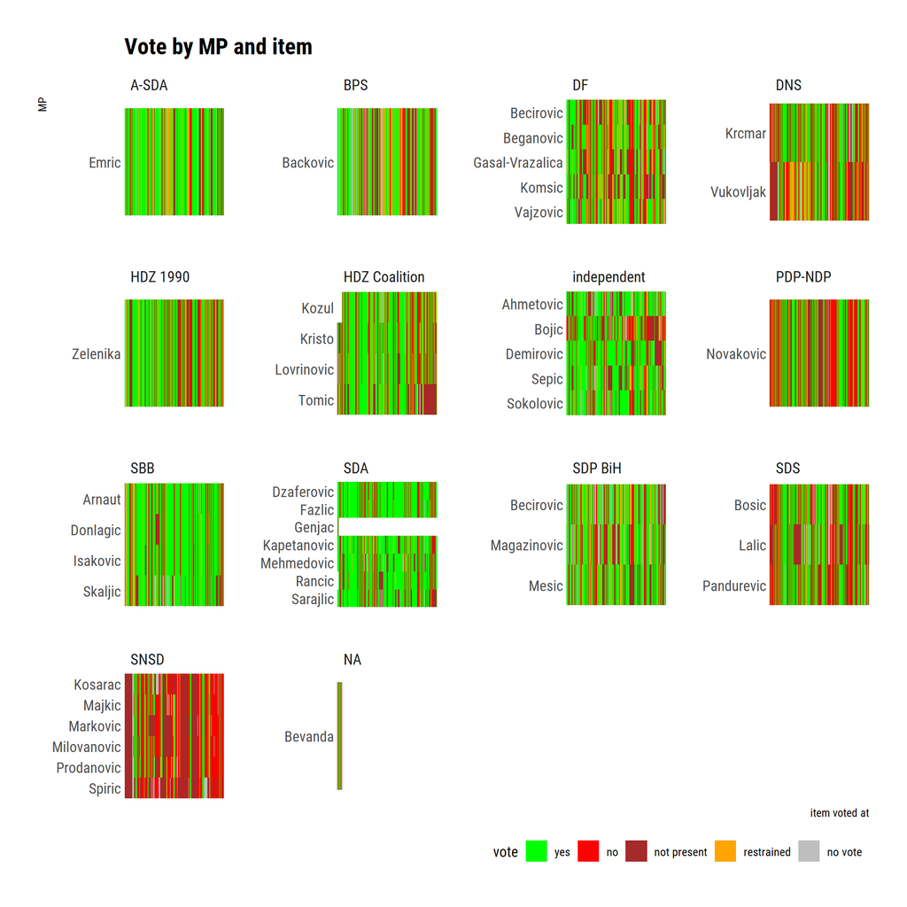